# Principal Component Analysis

and Dimension Reduction

# Introduction

In this document, we will demonstrate some dimension reduction techniques. In particulare, we will perform some Principal Component Analysis on data from the following article:

> “Sleep in Mammals: Ecological and Constitutional Correlates” by Allison, T. and Cicchetti, D. (1976), *Science*, November 12, vol. 194, pp. 732-734.

These data were obtained from the [StatLib](http://lib.stat.cmu.edu/datasets/) site. Here, we will focus on the following variables: animal species, body weight, brain weight, gestational length, and total sleep hours per day.

# Setup

We will use the following libraries.

```
library(tidyverse)
library(naniar)
library(GGally)
library(factoextra)
library(ggrepel)
```

# Prepare Data

We load in the data, add column names, deal with the missing values, and select complete cases of variables of interest.

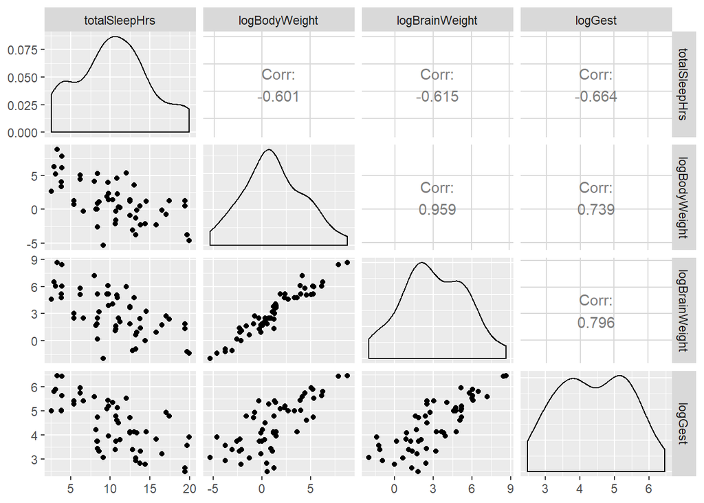

```r
# Load in the data
sleep <-
  read_csv("../data/sleep.csv",
           col_names = c("species", "bodyweight",  "brainweight",
                         "slowwave",  "paradoxical", "totalSleepHrs",
                         "maxlife", "gest",  "pred", "expos", "danger"),
           col_types = cols())

# Select variables of interest.   Deal with missing data (drop them)
dat <-
  sleep %>%
  select(species, bodyweight, brainweight, gest, totalSleepHrs) %>%
  replace_with_na_all(condition = ~.x == -999) %>%
  drop_na()

# Apply log transformations to right-skewed variables
transformed_dat <-
  dat %>%
  mutate(logBodyWeight = log(bodyweight)) %>%
  mutate(logBrainWeight = log(brainweight)) %>%
  mutate(logGest = log(gest)) %>%
  select(-bodyweight, -brainweight, -gest)

# Check
ggpairs(transformed_dat %>% select(-species))
```

# Principal Component Analysis

Before we perform the principal component analysis (PCA), we note that our four numeric variables (`totalSleepHrs`, `logBodyWeight`, `logBrainWeight`, and `logGest`) each have a certain amount of variation. However, in the pairs plot above, we notice that the variation of `logBodyWeight` is closely related to the variation of `logBrainWeight`. With PCA, we can execute a change of coordinates so that the variation that is spread out over four dimensions in our original coordinate system (`totalSleepHrs`, `logBodyWeight`, `logBrainWeight`, and `logGest`) can be (mostly) concentrated over two dimensions in our coordinate system of the transformed variables (i.e., the first and second principal component axes).

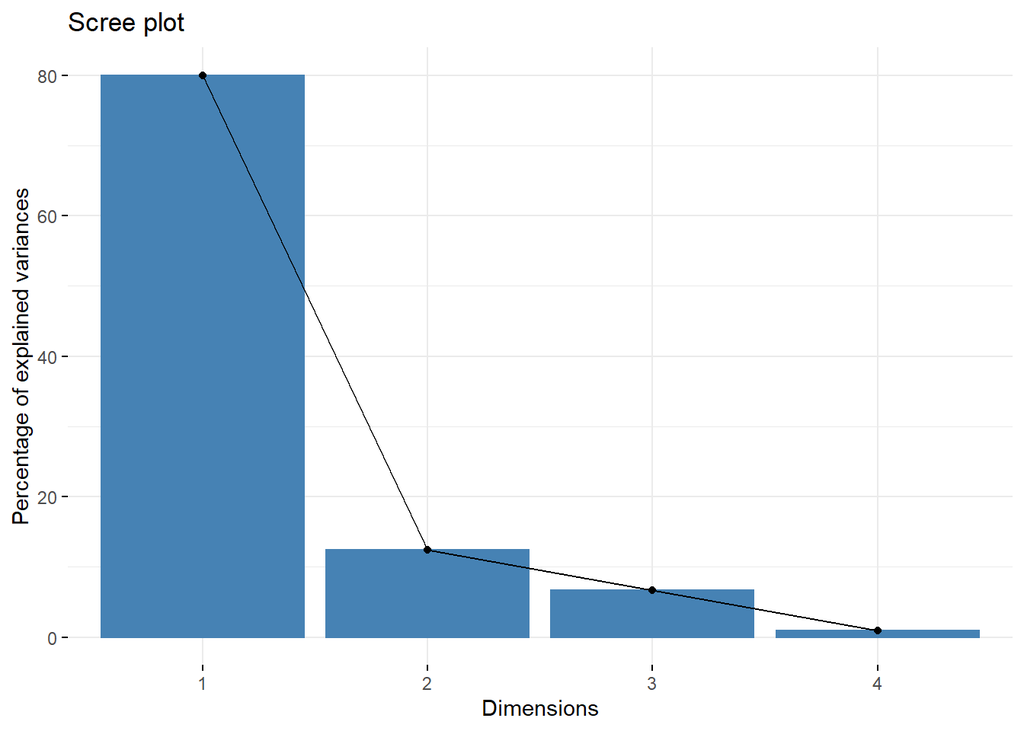

```r
# Isolate Numerical Data
num_dat <- transformed_dat %>% select(-species)
# Standardize the numerical data
scaled_num_dat <- scale(num_dat)
# Add Row Names to numerical data
rownames(scaled_num_dat) <- transformed_dat %>% pull(species)

# Perform PCA
res.pca <- prcomp(scaled_num_dat)

# Scree plot
fviz_eig(res.pca)
```

Indeed, when we project the 4 numerical dimensions of our species data (`totalSleepHrs`, `logBodyWeight`, `logBrainWeight`, and `logGest`) onto the first two principal component axes, then we are able to retain over 90% of the variance of the data in the original 4 numerical dimenstions, as seen in the scree plot above.

# The Rotation Matrix

Let’s examine our rotation matrix, also referred to as “the matrix of variable loadings.” This is a matrix whose columns contain eigenvectors which give us details about how to project the data from four dimensions to two.

```r
rot_mat <- res.pca$rotation
rot_mat
```

```
##                       PC1         PC2        PC3         PC4
## totalSleepHrs   0.4419904 -0.83491745  0.3273364  0.02020619
## logBodyWeight  -0.5207589 -0.40316790 -0.3657698  0.65763085
## logBrainWeight -0.5317258 -0.36755167 -0.1736588 -0.74297780
## logGest        -0.5007218  0.07262418  0.8537599  0.12287132
```

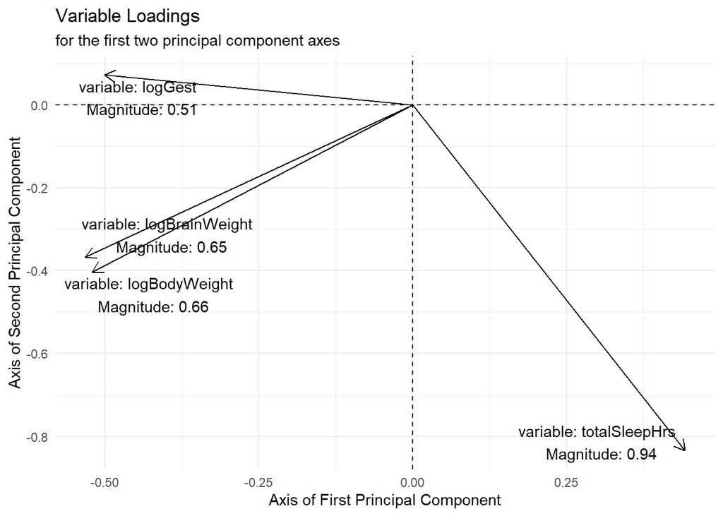

```r
# Visualization
rot_mat %>%
  as_tibble() %>%
  mutate(variable = row.names(rot_mat),
         length = sqrt(PC1^2 + PC2^2)) %>%
  ggplot(mapping = aes(x = 0,
                       xend = PC1,
                       y = 0,
                       yend = PC2)) +
  geom_segment(arrow = arrow(length = unit(0.03, "npc"))) +
  geom_text_repel(mapping = aes(label = paste0("variable: ",
                                               variable,
                                               " \n Magnitude: ",
                                               round(length,2)),
                                x = PC1,
                                y = PC2)) +
  theme_minimal() +
  labs(x = "Axis of First Principal Component",
       y = "Axis of Second Principal Component",
       title = "Variable Loadings",
       subtitle = "for the first two principal component axes"
  ) +
  geom_hline(yintercept = 0, linetype = "dashed") +
  geom_vline(xintercept = 0, linetype = "dashed")
```

# Coordinate Transformation

How do we actually transform our coordinates from the original system (`totalSleepHrs`, `logBodyWeight`, `logBrainWeight`, and `logGest`) to the “principal component system”?

Let’s look at an example.

Here are the scaled numerical values of the African Elephant, as a 1 x 4 matrix.

```r
scaled_num_dat[1,]
```

```
##  totalSleepHrs  logBodyWeight logBrainWeight        logGest
##      -1.553968       2.430490       2.238619       1.971500
```

Recall that these have been standardized (with a mean of zero and a standard deviation of one). We can see that the elephant has a large body weight and a large brain weight, but a very small amount of total sleep hours.

Now, remember the rotation matrix.

```r
res.pca$rotation
```

```
##                       PC1         PC2        PC3         PC4
## totalSleepHrs   0.4419904 -0.83491745  0.3273364  0.02020619
## logBodyWeight  -0.5207589 -0.40316790 -0.3657698  0.65763085
## logBrainWeight -0.5317258 -0.36755167 -0.1736588 -0.74297780
## logGest        -0.5007218  0.07262418  0.8537599  0.12287132
```

When we multiply the 1 x 4 matrix corresponding to the African Elephant with the rotation matrix, we obtain the transformed “PCA coordinates” of the African elephant.

```r
scaled_num_dat[1,] %*% res.pca$rotation
```

```
##            PC1        PC2        PC3       PC4
## [1,] -4.130043 -0.3620904 -0.1032379 0.1459618
```

Below, we will visualize the first two prinicpal component coordinates.

# Visualzations

Above, we manually obtained the PCA coordinates for the African elephant. We saw that the first two coordinates were approximately -4.13 and -0.36. We can plot these points in the $x-y$ plane, along with the PCA coordinates for all of the other species as follows.

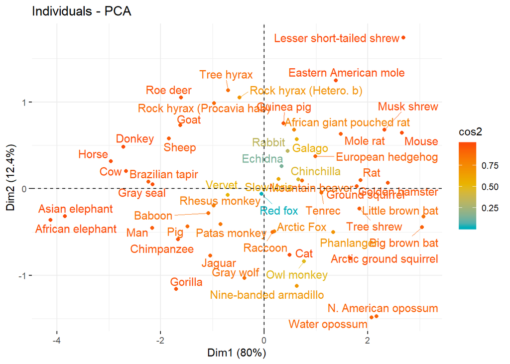

```r
fviz_pca_ind(res.pca,
             col.ind = "cos2", # Color by the quality of representation
             gradient.cols = c("#00AFBB", "#E7B800", "#FC4E07"),
             repel = TRUE     # Avoid text overlapping
)
```

If you look back at the visualization of the rotation matrix, you can get a sense of “why” a species ended up where it did in the plot above. For example, the elephants ended up around (-4, -.3) because they have large values for `logBrainWeight` and `logBodyWeight`, and so the eigenvectors corresponding to these two variables “pulled” the elephants in that direction when we transformed our coordinates from the original data to the PCA scale.

Meanwhile, the mice, rats, moles, and shrews have small values for `logBrainWeight` and `logBodyWeight`, and so the eigenvectors corresponding to these two variables “pushed” these animals away from the lower left quadrant when we transformed our coordinates from the original data to the PCA scale.

Likewise, the oppossums have large values for `totalSleepHrs`. Therefore, the eigenvector corresponding to this variable pulled the opposums near the PCA coordaintes of (2,-1.5).

# Conclusion

We have seen that Principal Component Analysis is a technique that can be used to project data that lives in $k$ dimenstions $(k>2)$ down to $2$ dimensions. In this sense, it can be a handy technique to keep in your back pocket when doing data science.